# Appendix 4: Documentation of Code

Max Harleman, Chris Moloney, Minbae Lee, Dan Kardish, Andrew Morgan

April 8, 2019

# 1. Data Cleaning and Setup:

## 1.1 Removing Heavily Correlated Features

```r
## Creating a county by year row names
  country= human.freedom.index$countries
  year= human.freedom.index$year
  co_year= paste(country, year, sep = " ", collapse = NULL)
  human.freedom.index= data.frame(co_year, human.freedom.index)
  human.freedom.index$ISO_code <- NULL
  human.freedom.index$countries <- NULL
  human.freedom.index$region <- NULL
  human.freedom.index$year <- NULL
  rownames(human.freedom.index)=human.freedom.index[,1]
  human.freedom.index$co_year <- NULL
```

## 1.2 Removing Columns with Many NAs

```r
cols.to.drop2 = list()    # will create list of column names to drop from dataset
list_counter = 1          # index for the list() object
for (i in 1:ncol(human.freedom.index)){
  # checking if the number of N/A's is 100 or more
  #     (seemed good with preliminary inspection)
  if(sum(is.na(human.freedom.index[,i])) >= 100 ){
    # append the column name that has 100+ N/A's
    cols.to.drop2[[list_counter]] = colnames(human.freedom.index[i])
    list_counter = list_counter + 1     # update the counter
  }
}
# now to 'vectorize' the list by unlist()-ing
cols.to.drop2 = unlist(cols.to.drop2)
ncol(human.freedom.index)   # number of features BEFORE dropping
```

```
## [1] 97
```

```r
human.freedom.index = human.freedom.index %>%
  dplyr::select(-cols.to.drop2)
```

[output not shown]

```r
ncol(human.freedom.index)   # number of features AFTER dropping due to NAs
```

```
## [1] 42
```

```r
nrow(human.freedom.index)   # number of rows BEFORE dropping
```

```
## [1] 1458
```

```r
# drop rows with ANY N/A's (this will bias the dataset)
human.freedom.index = human.freedom.index %>% na.omit()
nrow(human.freedom.index)   # number of rows AFTER dropping due to NAs
```

```
## [1] 1305
```

## 1.4 Creating Dataframes for Analysis:

```r
# vector of all column names that are responses (or forms of the responses)
responses = c("hf_score", "hf_rank", "hf_quartile")
# vector of main response
main.response = responses[1]
# vector of all non-features MINUS hf_score (primary response is retained)
other.response = responses[-1]

# dataframe of features
hfi.features = human.freedom.index %>%
  dplyr::select(-responses)
```

[output not shown]

```r
# dataframe of main response
hfi.response = human.freedom.index %>%
  dplyr::select(main.response)
```

[output not shown]

```r
# dataframe of features AND hf_score
hfi.combined = human.freedom.index %>% dplyr::select(-other.response)
```

[output not shown]

```r
# get the number of rows/cols in each
nrow(hfi.response)
```

```
## [1] 1305
```

```r
nrow(hfi.features)
```

```
## [1] 1305
```

```r
ncol(hfi.response)
```

```
## [1] 1
```

```r
ncol(hfi.features)
```

```
## [1] 39
```

## 1.5 Creating Train and Test Sets

```r
# set the seed to
set.seed(111)
hfi.combined.train = hfi.combined %>% sample_frac(size = .8)
hfi.combined.test = hfi.combined %>% setdiff(hfi.combined.train)
tss.hf_score = mean((mean(hfi.combined$hf_score) -
                        hfi.combined$hf_score)^2)
tss.test.hf_score = mean((mean(hfi.combined.test$hf_score) -
                        hfi.combined.test$hf_score)^2)
# Total Sum of Squares AVERAGED (since we are dealing with MSE)
tss.hf_score
```

```
## [1] 0.9762658
```

```r
tss.test.hf_score
```

```
## [1] 0.882886
```

This separates into a 80-20 split between train-test sets. Then, we get the TSS for all residuals of the test set. This can then be used to get an R^2 with the test set later on. The test set tss TSS 0.882886.

```r
rm(list_counter, main.response, other.response, responses)
```

# 2. Linear Regression and Model Selection Methods:

## 2.1 Train Test Split Estimates of Error

### 2.1.1 Linear Regression with all 39 Predictors

```r
lm.fit = lm(hf_score ~ ., data = hfi.combined.train)
lm.preds = predict(lm.fit, newdata = hfi.combined.test)
# get MSE and R^2 (just 1 - MSE/MEAN(TSS) === 1 - RSS/TSS)
mse.lm = mean((lm.preds - hfi.combined.test$hf_score)^2)
lm.r2 = 1 - (mse.lm/tss.test.hf_score)
mse.lm
```

```
## [1] 0.04212529
```

```r
fit1= mse.lm
summary(lm.fit)
```

```
##
## Call:
## lm(formula = hf_score ~ ., data = hfi.combined.train)
##
## Residuals:
##      Min       1Q   Median       3Q      Max
## -0.66748 -0.12628  0.01173  0.13001  0.86960
##
## Coefficients:
##                                    Estimate Std. Error t value Pr(>|t|)
## (Intercept)                        0.145580   0.140377   1.037 0.299955
## pf_ss_homicide                     0.051723   0.003014  17.160  < 2e-16 ***
## pf_ss_disappearances_disap         0.008234   0.002651   3.107 0.001946 **
## pf_ss_disappearances_violent       0.011537   0.005834   1.978 0.048239 *
## pf_ss_disappearances_fatalities    0.013678   0.008519   1.606 0.108671
## pf_ss_disappearances_injuries     -0.011447   0.009631  -1.189 0.234908
## pf_movement_domestic               0.018647   0.002438   7.648 4.77e-14 ***
## pf_movement_foreign                0.016603   0.002282   7.275 6.95e-13 ***
## pf_religion_harassment             0.024346   0.009549   2.550 0.010935 *
## pf_religion_restrictions           0.026060   0.005301   4.917 1.03e-06 ***
## pf_expression_killed               0.004401   0.003184   1.382 0.167268
## pf_expression_jailed               0.004549   0.005829   0.780 0.435317
## pf_expression_influence            0.041902   0.007332   5.715 1.44e-08 ***
## pf_expression_control              0.051388   0.008841   5.813 8.25e-09 ***
## pf_identity_sex_male               0.021640   0.002386   9.068  < 2e-16 ***
## pf_identity_sex_female             0.016773   0.002625   6.390 2.53e-10 ***
## ef_government_consumption          0.039532   0.003942  10.028  < 2e-16 ***
## ef_legal_courts                    0.071840   0.005959  12.055  < 2e-16 ***
## ef_legal_military                  0.043114   0.004214  10.231  < 2e-16 ***
## ef_legal_enforcement               0.048993   0.005263   9.308  < 2e-16 ***
## ef_legal_gender                    1.017024   0.067049  15.168  < 2e-16 ***
## ef_money_growth                    0.030594   0.007299   4.191 3.02e-05 ***
## ef_money_sd                        0.036258   0.005587   6.489 1.35e-10 ***
## ef_money_inflation                 0.030643   0.006775   4.523 6.82e-06 ***
## ef_money_currency                  0.025299   0.002465  10.264  < 2e-16 ***
## ef_trade_tariffs_mean              0.050615   0.012380   4.088 4.69e-05 ***
## ef_trade_tariffs_sd               -0.005233   0.005727  -0.914 0.361044
## ef_trade_tariffs                   0.013877   0.013001   1.067 0.286086
## ef_trade_regulatory_compliance     0.011715   0.008559   1.369 0.171372
## ef_trade_regulatory                0.040930   0.013653   2.998 0.002785 **
## ef_trade_black                     0.010401   0.006560   1.585 0.113201
## ef_trade_movement_capital          0.016325   0.003249   5.025 5.97e-07 ***
## ef_trade_movement_visit            0.017692   0.002434   7.268 7.32e-13 ***
## ef_regulation_credit_private       0.008449   0.004236   1.994 0.046370 *
## ef_regulation_credit               0.034903   0.008171   4.271 2.13e-05 ***
## ef_regulation_labor_minwage        0.003911   0.002879   1.359 0.174595
## ef_regulation_labor_hours          0.012914   0.003695   3.496 0.000494 ***
## ef_regulation_labor_conscription   0.005649   0.001774   3.185 0.001493 **
## ef_regulation_business_start       0.021423   0.007337   2.920 0.003581 **
## ef_regulation_business_compliance  0.002518   0.004158   0.605 0.544994
## ---
## Signif. codes:  0 '***' 0.001 '**' 0.01 '*' 0.05 '.' 0.1 ' ' 1
##
## Residual standard error: 0.2001 on 1004 degrees of freedom
## Multiple R-squared:  0.9615, Adjusted R-squared:   0.96
## F-statistic: 642.8 on 39 and 1004 DF,  p-value: < 2.2e-16
```

The R^2 of the FULL model using Linear Regression is: 0.9522868. This is very high, and shows there is a lot of potential trying to predict with this dataset.

### 2.1.2 Best Subset Selection

```r
set.seed(111)
max.predictors.for.bestsubset = ncol(hfi.features)
best.subsets.reg = regsubsets(hf_score ~ ., data = hfi.combined.train,
                              nvmax = max.predictors.for.bestsubset,
                              intercept = TRUE)
# store the results of the best-subset regressions
result = summary(best.subsets.reg)
# [commented out] this prints the various RSS's of best-subset
```

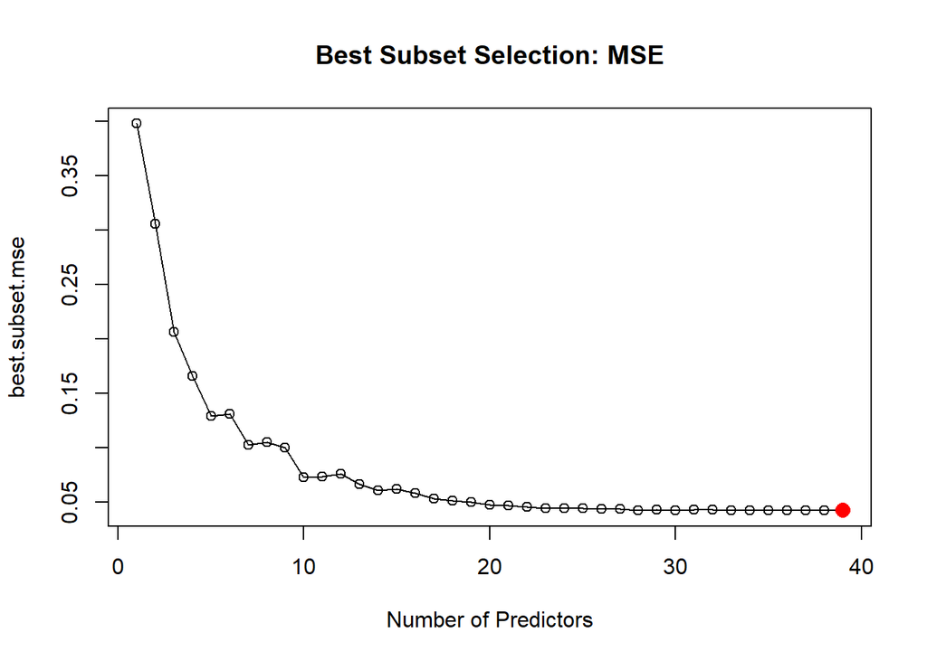

```
## integer(0)
```

```r
# vars for MSE and AIC for test sets
set.seed(111)
best.subset.mse = rep(-1, max.predictors.for.bestsubset)
best.subset.mse.aic = rep(-1, max.predictors.for.bestsubset)

for (i in 1:max.predictors.for.bestsubset){
  coef.i = coef(best.subsets.reg, id = i)
  temp.pred = as.matrix(
    hfi.combined.test[,colnames(hfi.combined.test) %in% names(coef.i)] ) %*%
    coef.i[names(coef.i) %in% colnames(hfi.combined.test)]
  temp.pred = as.vector(temp.pred) + coef.i["(Intercept)"]
  # MSE = RSS / N (Average of Residuals)
  best.subset.mse[i] = mean((temp.pred- hfi.combined.test$hf_score )^2)
  # AIC = 2*P + N * LOG(RSS/N) === 2*P + N * LOG(MSE)
  # P = # predictors; N = number of obs in test set

  best.subset.mse.aic[i] = 2*i +
    nrow(hfi.combined.test) * log(best.subset.mse[i], base = 10)
}

# plot the regular MSE With highlighted min. point
plot(best.subset.mse, main = "Best Subset Selection: MSE",
     xlab = 'Number of Predictors') +
  lines(x = 1:max.predictors.for.bestsubset, y=best.subset.mse) +
  points(x=which.min(best.subset.mse),
         y=best.subset.mse[which.min(best.subset.mse)],
         col = "red", pch = 16, cex = 1.5)
```

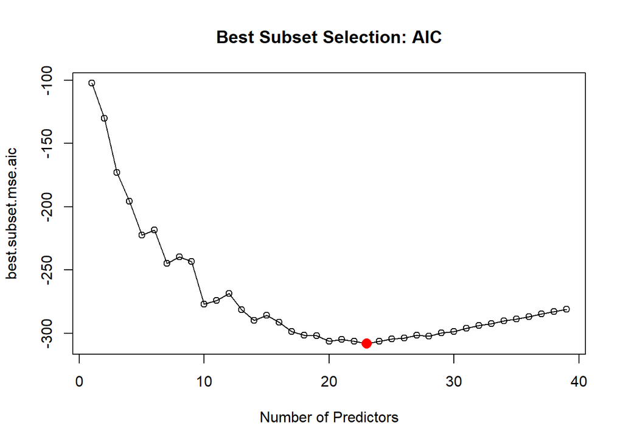

```
## integer(0)
```

```r
# plot the AIC results With highlighted min. point
plot(best.subset.mse.aic, main = "Best Subset Selection: AIC",
     xlab = 'Number of Predictors') +
  lines(x = 1:max.predictors.for.bestsubset, y=best.subset.mse.aic) +
  points(x=which.min(best.subset.mse.aic),
         y=best.subset.mse.aic[which.min(best.subset.mse.aic)],
         col = "red", pch = 16, cex = 1.5)
```

```r
best.subset.mse[which.min(best.subset.mse)]
```

```
## [1] 0.04212529
```

```r
best.subset.mse.aic[which.min(best.subset.mse.aic)]
```

```
## [1] -308.0917
```

```r
which.min(best.subset.mse)
```

```
## [1] 39
```

```r
which.min(best.subset.mse.aic)
```

```
## [1] 23
```

```r
fit5=best.subset.mse[which.min(best.subset.mse)]
```

### 2.1.3 Forward Model Selection

Probably better approach than backwards, since we want to eliminate the most variables in order to find a sparse list of features to predict HFI score.

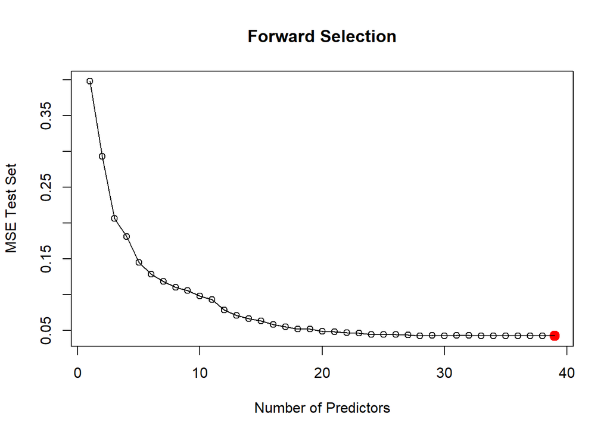

```
## integer(0)
```

```r
set.seed(111)
# set to 'forward' selection, allow max variables to be added
forward.fit = regsubsets(hf_score ~ ., method = "forward",
                         nvmax = ncol(hfi.features), data = hfi.combined.train)
# create test model matrix to easily create the predictions
test.model.matrix = model.matrix(hf_score ~ ., data = hfi.combined.test)
# stor MSE and AIC results for the test set
mse.forward = rep(-1, ncol(hfi.features))
aic.mse.forward = rep(-1, ncol(hfi.features))

for( i in 1:ncol(hfi.features)){
  # AGAIN, using pipes to efficiently create predictions
  coef.i = coef(forward.fit, id = i)
  preds = test.model.matrix[,names(coef.i)] %*% coef.i
  # create the MSE and then AIC
  mse.forward[i] = mean((preds - hfi.combined.test$hf_score)^2)
  aic.mse.forward[i] = 2*length(coef.i) +
    (nrow(hfi.combined.test))*log(mse.forward[i], base = 10)
}

# Plot the MSE and AIC results with the minimum point highlighted
plot(x = 1:ncol(hfi.features), y = mse.forward, main = "Forward Selection",
     ylab = "MSE Test Set", xlab = "Number of Predictors") +
  points(x = which.min(mse.forward),
         y = mse.forward[which.min(mse.forward)],
         col="red", pch=19, cex = 1.5) +
  lines(x = 1:ncol(hfi.features), y = mse.forward)
```

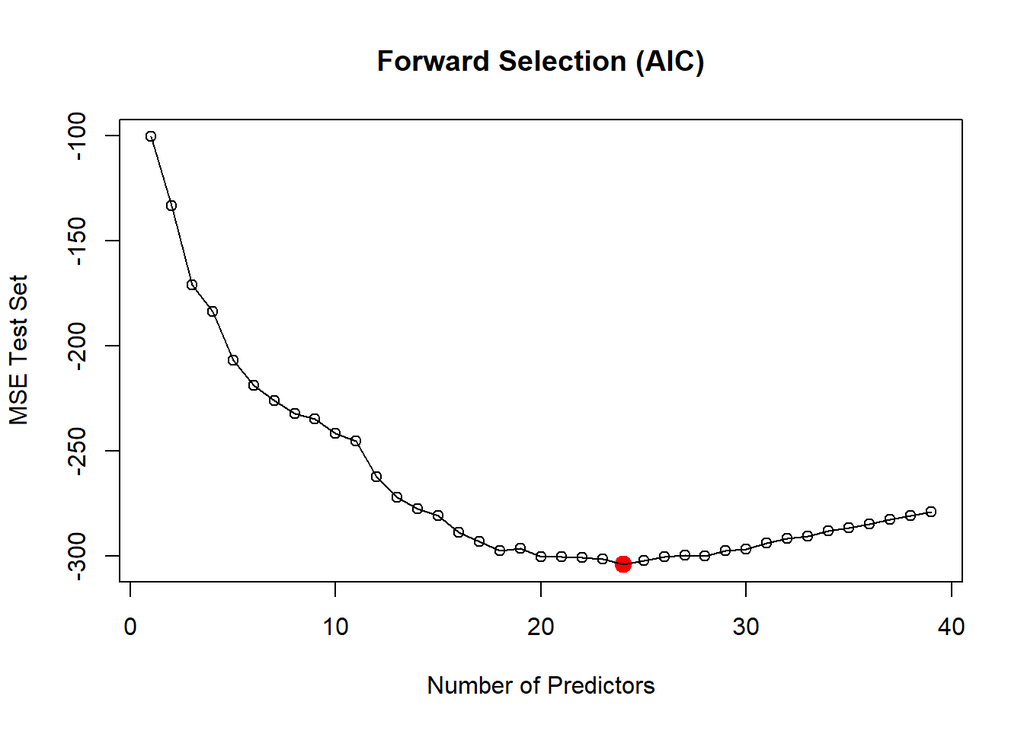

```
## integer(0)
```

```r
plot(x = 1:ncol(hfi.features), y = aic.mse.forward, main = "Forward Selection (AIC)",
     ylab = "MSE Test Set", xlab = "Number of Predictors") +
  points(x = which.min(aic.mse.forward),
         y = aic.mse.forward[which.min(aic.mse.forward)],
         col="red", pch=19, cex = 1.5) +
  lines(x = 1:ncol(hfi.features), y = aic.mse.forward)
```

```r
mse.forward[which.min(mse.forward)]
```

```
## [1] 0.04212529
```

```r
aic.mse.forward[which.min(aic.mse.forward)]
```

```
## [1] -304.0694
```

```r
which.min(mse.forward)
```

```
## [1] 39
```

```r
which.min(aic.mse.forward)
```

```
## [1] 24
```

```r
fit3=mse.forward[which.min(mse.forward)]
```

We utilize a forward model selection method that uses training RSS to define the best model of each size. The model with the lowest test MSE of 0.0421253includes 39 predictors. Like best subset, after reaching about 10 predictors, the test MSE starts flattening as additional predictors are added. Overall, the best subset is relatively good at showing most important factors in hf_score.

## 2.2 Cross Validation Estimates of Error

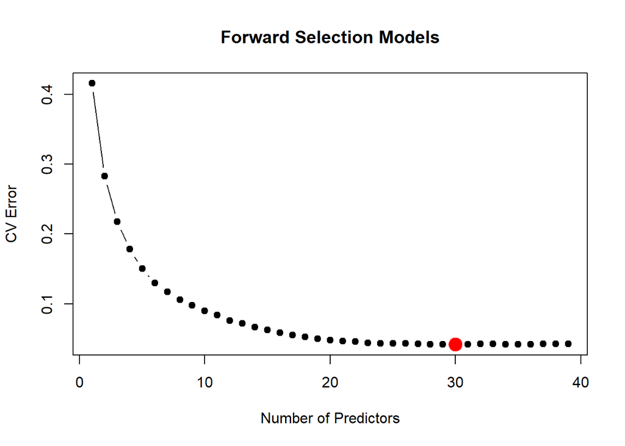

```r
set.seed(111)
# Set the number of folds for CV
# This code collects the models as formulas that from forward and best-subset selection
# The goal is to then take the formulas and run cross-validation

cv.best.subset.err<- rep(NA, ncol(hfi.features))
cv.forward.err<- rep(NA, ncol(hfi.features))

number.of.folds = 10

for(i in 1:ncol(hfi.features)){

formula.forward.mse = paste(names(coef(forward.fit, id = i))[-1],
                             collapse = " + " )
formula.forward.mse = as.formula( paste("hf_score ~ ", formula.forward.mse, sep = ""))


formula.best.sub.mse = paste( names(coef(best.subsets.reg,
                                         id = i))[-1],
                                collapse = " + " )
formula.best.sub.mse = as.formula( paste("hf_score ~ ", formula.best.sub.mse, sep = ""))


# NOW, use the GLM (generalized linear models) to calculate the Cross-Validated MSE

cv.forward = cv.glm(data = hfi.combined, K = number.of.folds,
                        glmfit = glm(formula = formula.forward.mse, data = hfi.combined))

cv.forward.err[i] = cv.forward$delta[1]


cv.best.subset = cv.glm(data = hfi.combined, K = number.of.folds,
                        glmfit = glm(formula = formula.best.sub.mse, data = hfi.combined))

cv.best.subset.err[i]= cv.best.subset$delta[1]

}

cv.full.lm = cv.glm(data = hfi.combined, K = number.of.folds,
                    glmfit = glm(formula = hf_score ~ ., data = hfi.combined))

cv.full.lm.err = cv.full.lm$delta[1]

plot(cv.forward.err, main="Forward Selection Models", xlab = "Number of Predictors", ylab = "CV Error", pch = 19, type = "b")
points (which.min(cv.forward.err),cv.forward.err [which.min(cv.forward.err)], col ="red",cex=2,pch =19)
```

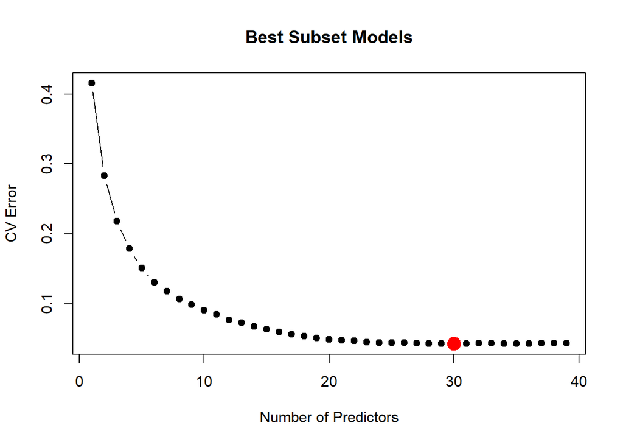

```r
plot(cv.forward.err, main="Best Subset Models", xlab = "Number of Predictors", ylab = "CV Error", pch = 19, type = "b")
points (which.min(cv.best.subset.err),cv.best.subset.err[which.min(cv.best.subset.err)], col ="red",cex=2,pch =19)
```

```r
# These are the errors from the best subset models with the lowest errors:
 which.min(cv.forward.err)
```

```
## [1] 30
```

```r
 cv.forward.err [which.min(cv.forward.err)]
```

```
## [1] 0.04158148
```

```r
 fit4=cv.forward.err [which.min(cv.forward.err)]
 which.min(cv.best.subset.err)
```

```
## [1] 30
```

```r
 cv.best.subset.err[which.min(cv.best.subset.err)]
```

```
## [1] 0.04152768
```

```r
 fit6= cv.best.subset.err[which.min(cv.best.subset.err)]
 ncol(hfi.features)
```

```
## [1] 39
```

```r
 cv.full.lm.err
```

```
## [1] 0.04182746
```

```r
 fit2= cv.full.lm.err
 tss.hf_score
```

```
## [1] 0.9762658
```

```r
coef(forward.fit,  which.min(cv.best.subset.err))
```

```
##                      (Intercept)                   pf_ss_homicide
##                      0.196938844                      0.053310969
##       pf_ss_disappearances_disap     pf_ss_disappearances_violent
##                      0.007980719                      0.015679642
##             pf_movement_domestic              pf_movement_foreign
##                      0.019167245                      0.016563058
##           pf_religion_harassment         pf_religion_restrictions
##                      0.024439470                      0.025080721
##          pf_expression_influence            pf_expression_control
##                      0.042098019                      0.052529550
##             pf_identity_sex_male           pf_identity_sex_female
##                      0.021745107                      0.016641440
##        ef_government_consumption                  ef_legal_courts
##                      0.039393411                      0.073688129
##                ef_legal_military             ef_legal_enforcement
##                      0.042804857                      0.049304768
##                  ef_legal_gender                  ef_money_growth
##                      1.030779245                      0.030126790
##                      ef_money_sd               ef_money_inflation
##                      0.034086607                      0.031006892
##                ef_money_currency            ef_trade_tariffs_mean
##                      0.025844394                      0.056652051
##              ef_trade_regulatory                   ef_trade_black
##                      0.059622394                      0.011423114
##        ef_trade_movement_capital          ef_trade_movement_visit
##                      0.016094784                      0.018370388
##     ef_regulation_credit_private             ef_regulation_credit
##                      0.008437005                      0.034837550
##        ef_regulation_labor_hours ef_regulation_labor_conscription
##                      0.013633784                      0.005587802
##     ef_regulation_business_start
##                      0.022342579
```

```r
coef(best.subsets.reg, which.min(cv.forward.err))
```

```
##                      (Intercept)                   pf_ss_homicide
##                      0.196938839                      0.053310969
##       pf_ss_disappearances_disap     pf_ss_disappearances_violent
##                      0.007980719                      0.015679642
##             pf_movement_domestic              pf_movement_foreign
##                      0.019167245                      0.016563058
##           pf_religion_harassment         pf_religion_restrictions
##                      0.024439470                      0.025080722
##          pf_expression_influence            pf_expression_control
##                      0.042098019                      0.052529551
##             pf_identity_sex_male           pf_identity_sex_female
##                      0.021745107                      0.016641440
##        ef_government_consumption                  ef_legal_courts
##                      0.039393411                      0.073688129
##                ef_legal_military             ef_legal_enforcement
##                      0.042804857                      0.049304768
##                  ef_legal_gender                  ef_money_growth
##                      1.030779242                      0.030126790
##                      ef_money_sd               ef_money_inflation
##                      0.034086607                      0.031006892
##                ef_money_currency            ef_trade_tariffs_mean
##                      0.025844394                      0.056652051
##              ef_trade_regulatory                   ef_trade_black
##                      0.059622394                      0.011423114
##        ef_trade_movement_capital          ef_trade_movement_visit
##                      0.016094784                      0.018370388
##     ef_regulation_credit_private             ef_regulation_credit
##                      0.008437005                      0.034837550
##        ef_regulation_labor_hours ef_regulation_labor_conscription
##                      0.013633784                      0.005587802
##     ef_regulation_business_start
##                      0.022342579
```

It is encouraging that the models with the lowest 10-fold CV Error in forward and best subset selection selection include mostly the same predictors. They also show similar curves, in which reductions in 10-fold CV Error level off after adding about 10 predictors.

```r
rm(human.freedom.index, cv.best.subset, cv.forward, cv.full.lm, forward.fit, lm.fit, preds, result, test.model.matrix, aic.mse.forward, best.subset.mse, best.subset.mse.aic, coef.i, cv.best.subset.err, cv.forward.err, cv.full.lm.err, formula.best.sub.mse, formula.forward.mse, i, lm.preds, lm.r2, max.predictors.for.bestsubset, mse.forward, mse.lm, number.of.folds, temp.pred)
```

# 3 Additional Linear Model Selection and Regularization Methods:

## 3.1 Shrinkage Methods

### 3.1.1 Ridge Regression

```r
set.seed(111)
# grid holds the range of LAMBDA values we use
grid = 10^seq(10,-2, length = 1000)
# seperate into train and test MODEL.MATRIX objects (easier)
train.model = model.matrix(hf_score ~ ., data = hfi.combined.train)[,-1]
test.model = model.matrix(hf_score ~ ., data = hfi.combined.test)[,-1]

# Perform Cross-Validation and test on the test set to get MSE's

cv.ridge = cv.glmnet(train.model, hfi.combined.train$hf_score, alpha = 0,
                     lambda = grid, thresh = 1e-12)
ridge.model = glmnet(train.model, hfi.combined.train$hf_score, alpha = 0,
                     lambda = cv.ridge$lambda.min, thresh = 1e-12)

bestlam.ridge <- cv.ridge$lambda.min
bestlam.ridge
```

```
## [1] 0.03669142
```

```r
pred.ridge = predict(ridge.model, newx = test.model, s = cv.ridge$lambda.min)
mse.ridge = mean((hfi.combined.test$hf_score - pred.ridge)^2)

ridge.model$beta
```

```
## 39 x 1 sparse Matrix of class "dgCMatrix"
##                                             s0
## pf_ss_homicide                     0.048143239
## pf_ss_disappearances_disap         0.009107639
## pf_ss_disappearances_violent       0.010751955
## pf_ss_disappearances_fatalities    0.012108566
## pf_ss_disappearances_injuries     -0.008094916
## pf_movement_domestic               0.018365280
## pf_movement_foreign                0.016600531
## pf_religion_harassment             0.022107300
## pf_religion_restrictions           0.026782092
## pf_expression_killed               0.004940367
## pf_expression_jailed               0.005380067
## pf_expression_influence            0.040909831
## pf_expression_control              0.050735317
## pf_identity_sex_male               0.020631078
## pf_identity_sex_female             0.017276297
## ef_government_consumption          0.034299065
## ef_legal_courts                    0.067955677
## ef_legal_military                  0.040888903
## ef_legal_enforcement               0.049533817
## ef_legal_gender                    0.980300442
## ef_money_growth                    0.029226572
## ef_money_sd                        0.039288578
## ef_money_inflation                 0.027941977
## ef_money_currency                  0.023809489
## ef_trade_tariffs_mean              0.047530346
## ef_trade_tariffs_sd               -0.007878708
## ef_trade_tariffs                   0.023060196
## ef_trade_regulatory_compliance     0.014764128
## ef_trade_regulatory                0.037602317
## ef_trade_black                     0.012040169
## ef_trade_movement_capital          0.017686057
## ef_trade_movement_visit            0.016960368
## ef_regulation_credit_private       0.008702898
## ef_regulation_credit               0.033870605
## ef_regulation_labor_minwage        0.004212930
## ef_regulation_labor_hours          0.013373527
## ef_regulation_labor_conscription   0.005972801
## ef_regulation_business_start       0.024265085
## ef_regulation_business_compliance  0.004767761
```

```r
mse.ridge
```

```
## [1] 0.04268541
```

```r
fit7=mse.ridge
```

### 3.1.2 LASSO

```r
set.seed(111)
# perform same thing as Ridge but with alpha==1; get MSE's
cv.lasso = cv.glmnet(train.model, hfi.combined.train$hf_score, alpha = 1,
                     lambda = grid, thresh = 1e-12)
lasso.model = glmnet(train.model, hfi.combined.train$hf_score, alpha = 1,
                     lambda = cv.lasso$lambda.min, thresh = 1e-12)
bestlam.lasso <- cv.lasso$lambda.min
bestlam.lasso
```

```
## [1] 0.01
```

```r
pred.lasso = predict(cv.lasso, newx = test.model, s = cv.lasso$lambda.min)
mse.lasso = mean((hfi.combined.test$hf_score - pred.lasso)^2)

# this code counts number of parameters that were set to 0
sum.0s = 0
for( i in 1:length(lasso.model$beta[,1])){
  if(lasso.model$beta[i,1]==0 ){
    sum.0s = sum.0s + 1
  }
}
sum.0s
```

```
## [1] 4
```

```r
# then print the betas and MSE of best lambda
lasso.model$beta
```

```
## 39 x 1 sparse Matrix of class "dgCMatrix"
##                                             s0
## pf_ss_homicide                    0.0482721482
## pf_ss_disappearances_disap        0.0067916085
## pf_ss_disappearances_violent      0.0095460222
## pf_ss_disappearances_fatalities   0.0056994662
## pf_ss_disappearances_injuries     .
## pf_movement_domestic              0.0179469819
## pf_movement_foreign               0.0161888566
## pf_religion_harassment            0.0133583976
## pf_religion_restrictions          0.0232748250
## pf_expression_killed              0.0003338037
## pf_expression_jailed              .
## pf_expression_influence           0.0403804722
## pf_expression_control             0.0532926050
## pf_identity_sex_male              0.0204403510
## pf_identity_sex_female            0.0157921120
## ef_government_consumption         0.0277864294
## ef_legal_courts                   0.0673002557
## ef_legal_military                 0.0414556306
## ef_legal_enforcement              0.0479749071
## ef_legal_gender                   1.0322632473
## ef_money_growth                   0.0242324499
## ef_money_sd                       0.0384846282
## ef_money_inflation                0.0266885986
## ef_money_currency                 0.0250192094
## ef_trade_tariffs_mean             0.0532249188
## ef_trade_tariffs_sd               .
## ef_trade_tariffs                  0.0010439350
## ef_trade_regulatory_compliance    0.0077896008
## ef_trade_regulatory               0.0513389184
## ef_trade_black                    0.0104390450
## ef_trade_movement_capital         0.0167597272
## ef_trade_movement_visit           0.0166703576
## ef_regulation_credit_private      0.0012641058
## ef_regulation_credit              0.0429851627
## ef_regulation_labor_minwage       .
## ef_regulation_labor_hours         0.0102634608
## ef_regulation_labor_conscription  0.0045281405
## ef_regulation_business_start      0.0183367124
## ef_regulation_business_compliance 0.0011945114
```

```r
mse.lasso
```

```
## [1] 0.04306142
```

```r
fit8=mse.lasso
```

## 3.2 Dimension Reduction Methods

### 3.2.1 Principle Components Regression (PCR)

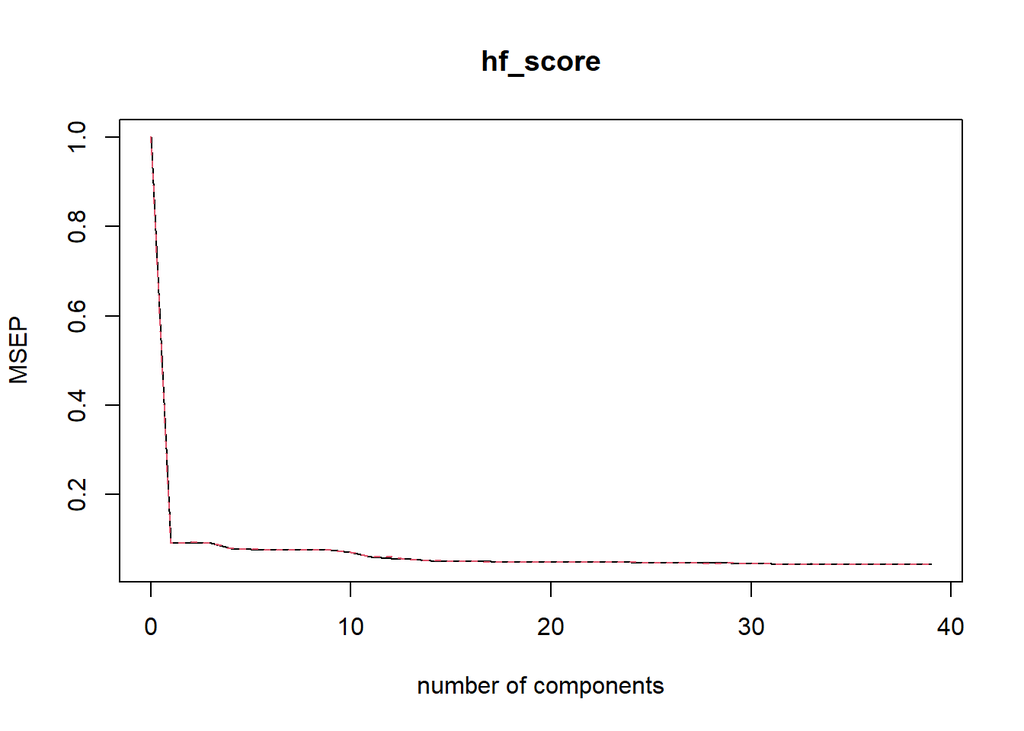

```r
set.seed(111)
# create model, then print validation plot and mse of best model
pcr.model = pcr(hf_score ~ . , data = hfi.combined.train, scale = TRUE,
                validation = "CV")
validationplot(pcr.model, val.type = "MSEP")
```

```r
summary(pcr.model)
```

```
## Data:    X dimension: 1044 39
##  Y dimension: 1044 1
## Fit method: svdpc
## Number of components considered: 39
##
## VALIDATION: RMSEP
## Cross-validated using 10 random segments.
##        (Intercept)  1 comps  2 comps  3 comps  4 comps  5 comps  6 comps
## CV           1.001   0.3028   0.3038   0.3017   0.2808   0.2789   0.2753
## adjCV        1.001   0.3026   0.3036   0.3016   0.2803   0.2786   0.2750
##        7 comps  8 comps  9 comps  10 comps  11 comps  12 comps  13 comps
## CV      0.2757   0.2752    0.276    0.2653    0.2467    0.2400    0.2339
## adjCV   0.2755   0.2750    0.276    0.2656    0.2455    0.2455    0.2325
##        14 comps  15 comps  16 comps  17 comps  18 comps  19 comps  20 comps
## CV       0.2267    0.2252    0.2251    0.2220    0.2214    0.2218    0.2203
## adjCV    0.2268    0.2246    0.2246    0.2213    0.2213    0.2214    0.2199
##        21 comps  22 comps  23 comps  24 comps  25 comps  26 comps  27 comps
## CV       0.2200    0.2188    0.2191    0.2186    0.2176    0.2148    0.2149
## adjCV    0.2197    0.2184    0.2188    0.2184    0.2174    0.2143    0.2146
##        28 comps  29 comps  30 comps  31 comps  32 comps  33 comps  34 comps
## CV       0.2142    0.2144    0.2135    0.2139    0.2099    0.2101    0.2092
## adjCV    0.2138    0.2141    0.2131    0.2135    0.2092    0.2094    0.2086
##        35 comps  36 comps  37 comps  38 comps  39 comps
## CV       0.2086    0.2086    0.2078    0.2080    0.2082
## adjCV    0.2081    0.2080    0.2071    0.2074    0.2075
##
## TRAINING: % variance explained
##           1 comps  2 comps  3 comps  4 comps  5 comps  6 comps  7 comps
## X           22.93    31.61    37.92    43.54    48.60    52.98    56.75
## hf_score    90.83    90.86    90.99    92.28    92.34    92.61    92.62
##           8 comps  9 comps  10 comps  11 comps  12 comps  13 comps  14 comps
## X           60.46    63.67     66.38     68.95     71.24     73.51     75.58
## hf_score    92.64    92.64     93.22     94.17     94.17     94.85     95.04
##           15 comps  16 comps  17 comps  18 comps  19 comps  20 comps  21 comps
## X            77.61     79.50     81.24     82.83     84.40     85.80     87.14
## hf_score     95.16     95.16     95.31     95.31     95.34     95.39     95.42
##           22 comps  23 comps  24 comps  25 comps  26 comps  27 comps  28 comps
## X            88.41     89.60     90.76     91.87     92.90     93.83     94.71
## hf_score     95.48     95.51     95.54     95.58     95.71     95.76     95.80
##           29 comps  30 comps  31 comps  32 comps  33 comps  34 comps  35 comps
## X            95.47     96.21     96.90     97.52     98.11     98.63     99.11
## hf_score     95.80     95.85     95.86     96.03     96.05     96.07     96.10
##           36 comps  37 comps  38 comps  39 comps
## X            99.52     99.76     99.90    100.00
## hf_score     96.11     96.15     96.15     96.15
```

```r
pcr.preds = predict(pcr.model, newdata = hfi.combined.test, ncomp = 37)
pcr.mse = mean((pcr.preds - hfi.combined.test$hf_score)^2)
pcr.mse
```

```
## [1] 0.04228319
```

```r
fit9=pcr.mse
```

Using 10-fold cross validation, the lowest average root MSE is the one corresponding to M=37 components.The resulting PCR gives a test MSE of 0.0422832, and is slightly higher than the test MSE of the full OLS model (0.0421253). Notably, the validation plot shows that after the first component is added, only marginal benefits are gained from adding more components.

### 3.2.2 Partial Least Squares (PLS)

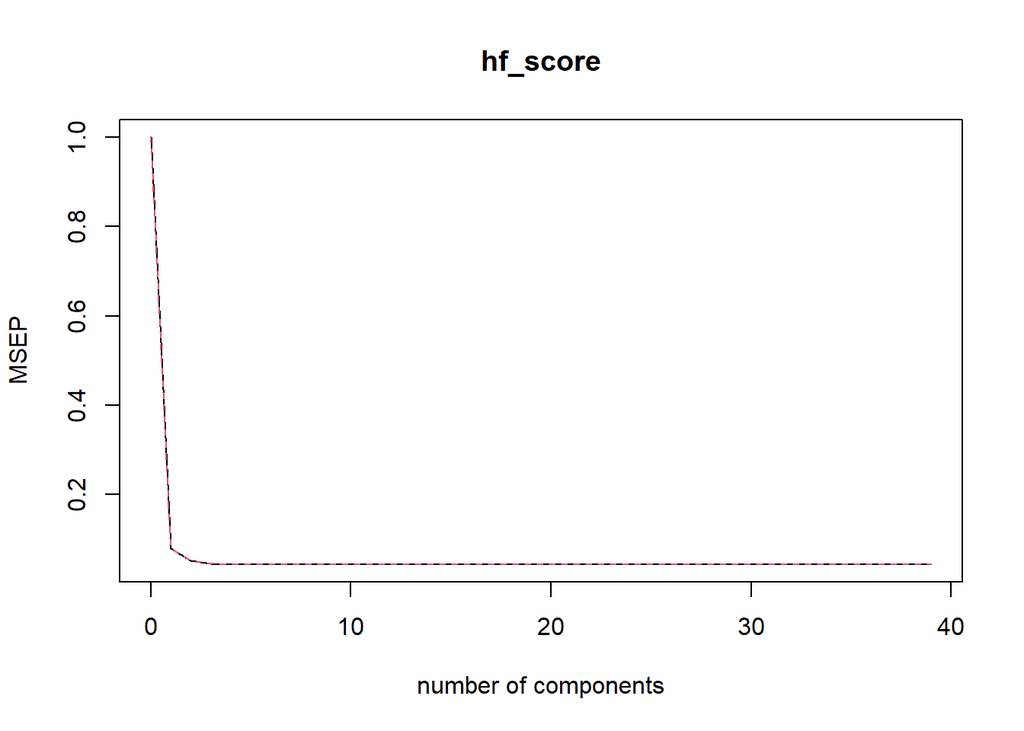

```r
set.seed(111)
# create pls model and plot validation; report the best mse
pls.model = plsr(hf_score ~ . , data = hfi.combined.train, scale = TRUE,
                 validation = "CV")
validationplot(pls.model, val.type = "MSEP")
```

```r
summary(pls.model)
```

```
## Data:    X dimension: 1044 39
##  Y dimension: 1044 1
## Fit method: kernelpls
## Number of components considered: 39
##
## VALIDATION: RMSEP
## Cross-validated using 10 random segments.
##        (Intercept)  1 comps  2 comps  3 comps  4 comps  5 comps  6 comps
## CV           1.001   0.2808   0.2268   0.2108   0.2095   0.2088   0.2084
## adjCV        1.001   0.2807   0.2262   0.2104   0.2092   0.2083   0.2078
##        7 comps  8 comps  9 comps  10 comps  11 comps  12 comps  13 comps
## CV      0.2082   0.2081   0.2080    0.2080    0.2081    0.2080    0.2081
## adjCV   0.2076   0.2075   0.2074    0.2074    0.2074    0.2074    0.2074
##        14 comps  15 comps  16 comps  17 comps  18 comps  19 comps  20 comps
## CV       0.2081    0.2081    0.2081    0.2082    0.2082    0.2082    0.2082
## adjCV    0.2074    0.2075    0.2075    0.2075    0.2075    0.2075    0.2075
##        21 comps  22 comps  23 comps  24 comps  25 comps  26 comps  27 comps
## CV       0.2082    0.2082    0.2082    0.2082    0.2082    0.2082    0.2082
## adjCV    0.2075    0.2075    0.2075    0.2075    0.2075    0.2075    0.2075
##        28 comps  29 comps  30 comps  31 comps  32 comps  33 comps  34 comps
## CV       0.2082    0.2082    0.2082    0.2082    0.2082    0.2082    0.2082
## adjCV    0.2075    0.2075    0.2075    0.2075    0.2075    0.2075    0.2075
##        35 comps  36 comps  37 comps  38 comps  39 comps
## CV       0.2082    0.2082    0.2082    0.2082    0.2082
## adjCV    0.2075    0.2075    0.2075    0.2075    0.2075
##
## TRAINING: % variance explained
##           1 comps  2 comps  3 comps  4 comps  5 comps  6 comps  7 comps
## X           22.90    27.59    31.69    38.52    41.64    45.62    49.34
## hf_score    92.19    95.17    95.86    95.98    96.09    96.12    96.13
##           8 comps  9 comps  10 comps  11 comps  12 comps  13 comps  14 comps
## X           52.57    54.73     58.14     60.43     63.06     65.15     66.86
## hf_score    96.14    96.15     96.15     96.15     96.15     96.15     96.15
##           15 comps  16 comps  17 comps  18 comps  19 comps  20 comps  21 comps
## X            68.61     70.54     72.64     74.42     76.46     78.28     79.64
## hf_score     96.15     96.15     96.15     96.15     96.15     96.15     96.15
##           22 comps  23 comps  24 comps  25 comps  26 comps  27 comps  28 comps
## X            80.75     81.86     83.11     84.34     85.29     86.18     87.64
## hf_score     96.15     96.15     96.15     96.15     96.15     96.15     96.15
##           29 comps  30 comps  31 comps  32 comps  33 comps  34 comps  35 comps
## X            88.83     90.25     91.81     92.83     93.78     94.75     96.01
## hf_score     96.15     96.15     96.15     96.15     96.15     96.15     96.15
##           36 comps  37 comps  38 comps  39 comps
## X            97.15     98.07     99.23    100.00
## hf_score     96.15     96.15     96.15     96.15
```

```r
pls.preds = predict(pls.model, newdata = hfi.combined.test, ncomp = 9)
pls.mse = mean((pls.preds - hfi.combined.test$hf_score)^2)
pls.mse
```

```
## [1] 0.04232898
```

```r
fit10=pls.mse
```

Using 10-fold cross validation, the lowest average root MSE is the one corresponding to M=9. The resulting PCR, the resulting test MSE is 0.042329, and is slightly higher than the test MSE of the full OLS model (0.0421253). The validation and the variance explained seem to go completely constant after 9 components. Again, the validation plot shows that after the first component is added, only marginal benefits are gained from adding more components.

```r
rm(cv.lasso, cv.ridge, lasso.model, pcr.model, pls.model, pred.lasso, pred.ridge, ridge.model, test.model, train.model, bestlam.lasso, bestlam.ridge, grid, i, mse.lasso, mse.ridge, pcr.mse, pcr.preds, pls.mse, pls.preds, sum.0s)
```